# statComp_hw7

# 9.4

The standard Laplace distribution has the form $f(x) = \frac{1}{2}e^{-|x|}$.

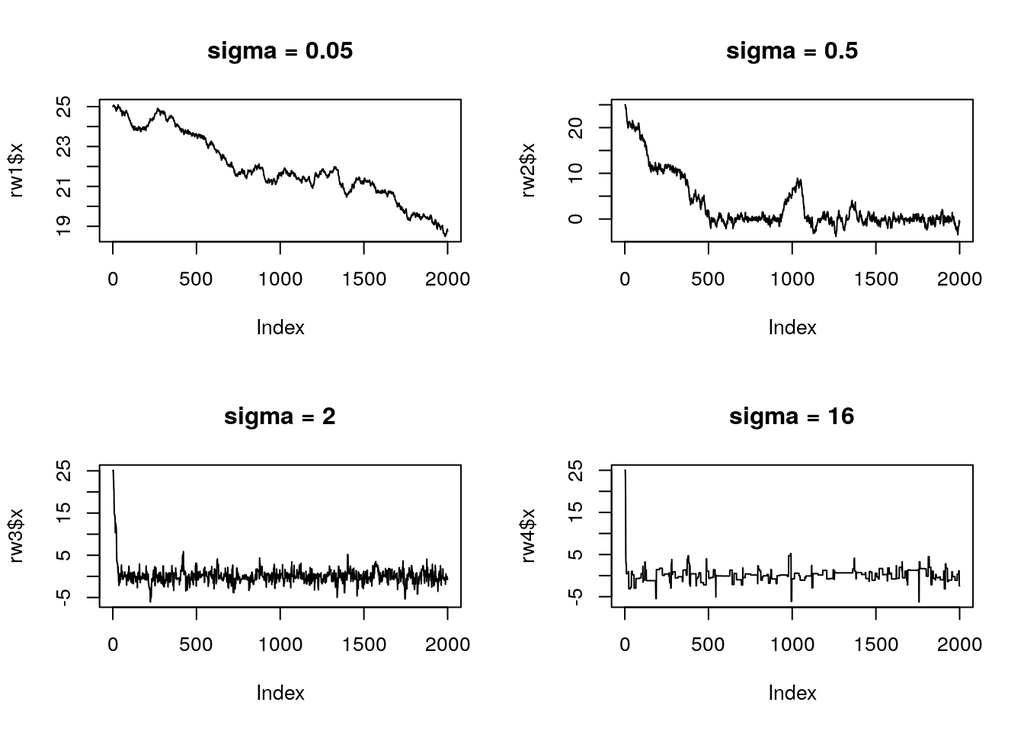

```r
f <- function(x) {
  0.5 * exp(-abs(x))
}

rw.Metropolis <- function(sigma, x0, N) {
  x <- numeric(N)
  x[1] <- x0
  u <- runif(N)
  k <- 0
  for (i in 2:N) {
    y <- rnorm(1, x[i-1], sigma)
    if (u[i] <= (f(y) / f(x[i-1])))
      x[i] <- y
    else {
      x[i] <- x[i-1]
      k <- k + 1
    }
  }
  return(list(x=x, k=k))
}

N <- 2000
sigma <- c(.05, .5, 2, 16)
x0 <- 25
rw1 <- rw.Metropolis(sigma[1], x0, N)
rw2 <- rw.Metropolis(sigma[2], x0, N)
rw3 <- rw.Metropolis(sigma[3], x0, N)
rw4 <- rw.Metropolis(sigma[4], x0, N)

par(mfrow=c(2,2))
plot(rw1$x, type = "l", main = "sigma = 0.05")
plot(rw2$x, type = "l", main = "sigma = 0.5")
plot(rw3$x, type = "l", main = "sigma = 2")
plot(rw4$x, type = "l", main = "sigma = 16")
```

The acceptance rates of each chain is shown below.

```r
#proportion of candidate points accepted
print(c(1-rw1$k/N, 1-rw2$k/N, 1-rw3$k/N, 1-rw4$k/N))
```

```
## [1] 0.9735 0.8260 0.5585 0.0950
```

# 2

Denote $\displaystyle x_{-j} =( x_{1} ,\cdots ,x_{j-1} ,x_{j+1} ,\cdots ,x_{n})$

In the $\displaystyle j$-th step of iteration $\displaystyle t$, the proposal in the is

$$\begin{equation*}
g\left( y_{j} |x^{( t-1)}\right) =\begin{cases}
f\left( y_{j} |x_{-j}^{( t-1)}\right) & if\ y_{-j} =x_{-j}^{( t-1)}\\
0 & else
\end{cases}
\end{equation*}$$

Thus the ratio at the $\displaystyle j$-th step of iteration $\displaystyle t$ is

$$\begin{align*}
r & =\frac{f( y) g\left( x^{( t-1)} |y_{j}\right)}{f\left( x^{( t-1)}\right) g\left( y_{j} |x^{( t-1)}\right)}\\
& =\frac{f( y) f\left( x_{-j}^{( t-1)} |y_{j}\right)}{f\left( x^{( t-1)}\right) f\left( y_{j} |x_{-j}^{( t-1)}\right)}\\
& =\frac{f( y_{j} ,y_{-j}) f\left( x_{-j}^{( t-1)} |y_{j}\right)}{f\left( x_{j}^{( t-1)} ,x_{-j}^{( t-1)}\right) f\left( y_{j} |x_{-j}^{( t-1)}\right)}\\
& =\frac{f( y_{j} |y_{-j}) f( y_{-j}) f\left( x_{-j}^{( t-1)} |y_{j}\right)}{f\left( x_{j}^{( t-1)} |x_{-j}^{( t-1)}\right) f\left( x_{-j}^{( t-1)}\right) f\left( y_{j} |x_{-j}^{( t-1)}\right)}\\
& =\frac{{f( y_{j} |y_{-j})}{f( y_{-j})}{f\left( x_{-j}^{( t-1)} |y_{j}\right)}}{{f\left( x_{j}^{( t-1)} |x_{-j}^{( t-1)}\right)}{f\left( x_{-j}^{( t-1)}\right)}{f\left( y_{j} |x_{-j}^{( t-1)}\right)}}\\
& =1
\end{align*}$$
The factors are eliminated because $\displaystyle y_{-j} =x_{-j}^{( t-1)}$.

Thus Gibbs sampling can be viewed as a special case of the Metropolis-Hastings algorithm. In Gibbs sampler, every newly proposed sample is accepted with probability one